# MSDS 6372 Project 2: Modeling Bank Customer Term Deposit Subscription Behavior to Improve Marketing Efforts

## Principal Component Analysis

```r
# Ignore duration, even though numeric, because it is not a valid predictor; it's leaky -- we only know duration at the END of the call
# numeric_vars <- bank_full %>% select(age, balance, campaign, pdays, previous)
# pca_result <- prcomp(numeric_vars, scale.=TRUE) # scale.=true means use the *Correlation matrix* instead of the covariance matrix
# pca_scores <- as.data.frame(pca_result$x[, 1:3])
# pca_scores$Subscribed <- bank_full$Subscribed
# pca_model <- glm(y ~ .,data=pca_scores, family="binomial")
# summary(pca_model)
```

```r
library(glmnet)
library(caret)
x <- model.matrix(Subscribed~age+job+education+marital+balance+contact+month+campaign+pdays+previous+poutcome, data=bank_full)[, -1]  # remove intercept column
y <- bank_full$Subscribed
y_numeric <- ifelse(y == "yes", 1, 0)
bank_full$month <- relevel(factor(bank_full$month), ref = "jan") # Make January the baseline month instead of April (R chooses April because alphabetical order)

lasso_model <- cv.glmnet(x, y_numeric, alpha=1, family="binomial") #  LASSO with cross-validation
coef(lasso_model, s="lambda.min")
```

```
## 34 x 1 sparse Matrix of class "dgCMatrix"
##                               s1
## (Intercept)        -1.800949e+00
## age                 3.274153e-03
## jobblue-collar     -1.632790e-01
## jobentrepreneur    -1.899022e-01
## jobhousemaid       -1.859117e-01
## jobmanagement       .
## jobretired          5.394095e-01
## jobself-employed   -2.589813e-02
## jobservices        -7.977563e-02
## jobstudent          6.204318e-01
## jobtechnician      -3.740661e-02
## jobunemployed       2.299719e-01
## educationsecondary  1.336128e-01
## educationtertiary   3.506663e-01
## maritalmarried     -1.886195e-01
## maritalsingle       1.824866e-01
## balance             2.255925e-05
## contacttelephone   -3.971300e-02
## monthaug           -5.107267e-01
## monthdec            7.702016e-01
## monthfeb           -2.507865e-01
## monthjan           -8.953216e-01
## monthjul           -5.797883e-01
## monthjun           -5.359173e-01
## monthmar            1.304195e+00
## monthmay           -1.022500e+00
## monthnov           -7.597952e-01
## monthoct            7.722652e-01
## monthsep            7.553915e-01
## campaign           -8.731710e-02
## pdays               2.325680e-04
## previous            9.788554e-03
## poutcomeother       3.256138e-01
## poutcomesuccess     2.400929e+00
```

Feature Selection using LASSO with Cross-Validation

Students have higher odds of subscribing.

Balance has predictive value, but surprisingly, it’s very weak compared to other variables. This is because balance is correlated with stronger predictors like job and education, so its unique contribution is small (0.0226 per €1000).

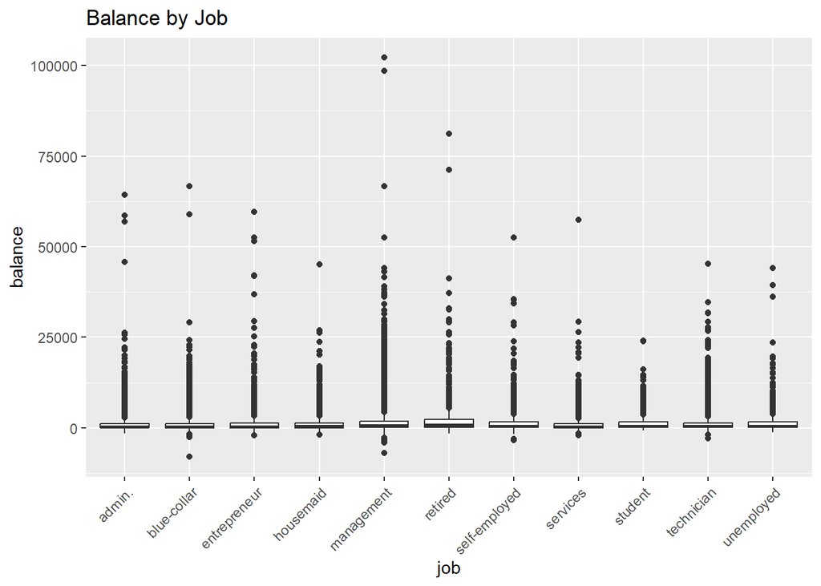

```r
ggplot(bank_full, aes(x = job, y = balance)) +  geom_boxplot() +  theme(axis.text.x = element_text(angle = 45, hjust = 1)) +  labs(title = "Balance by Job")
```

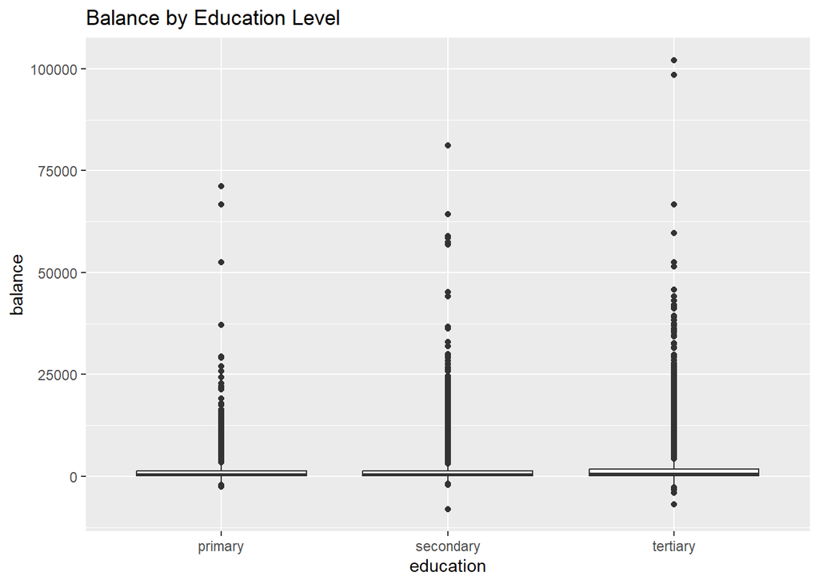

```r
ggplot(bank_full, aes(x = education, y = balance)) +  geom_boxplot() +  labs(title = "Balance by Education Level")
```

## Decision Boundary Investigation

```r
library(RSSL)
```

```r
set.seed(1234)
mydata<-generateCrescentMoon(200,2,2) # Generates 200 points shaped like a crescent moon (nonlinear structure).
# "2,2"
# 2 (first): radius or distance between the two crescents → controls spacing
# 2 (second): noise level → controls how much jitter or spread is added to the points
# mydata$Class<-factor(ifelse(mydata$Class=="+","Yes","No")) # renames class values if  + then Yes else No
# plot(mydata$X1,mydata$X2,col=mydata$Class,asp=1,pch=16,cex=.7,xlab="X1",ylab="X2")
```

## Unsupervised Learning

• Other UNSUPERVISED tools such as HEATMAPS and CLUSTER ANALYSIS from Unit 13 and 14.

## Clustering

• Clustering is optional.